# Dates, times and spatial data in R

Author

Ondrej Ledvinka

Published

April 16, 2024

Modified

April 16, 2024

## Lesson prerequisites

As usual, we are working within the R project established during the first lesson; therefore, we use relative paths to files. We also assume that we have some subfolders in the folder related to the project (e.g. for data, geodata, metadata, results, etc.). Good internet connection is required because we will load geographical data directly to R using various services.

If possible, we are working with the newest versions of R (currently, R version 4.3.3 (2024-02-29 ucrt) – Angel Food Cake from 2024-02-29) and RStudio (currently, RStudio 2023.12.1+402 Ocean Storm from 2024-01-29).

## Dates and times in R

It is highly advisable to know how to work with vectors and table columns representing dates (and sometimes also times) in R. We already met some strings resembling dates in our tables with metadata and discharge time series. From dates of release of the current versions of R and RStudio, we should also be aware of the fact what is the standard for typing date and times. The basic logic is that we first type longer temporal units, such as years, and the end of this ‘string’ is day in the case of date objects or second in the case of datetime object (after which we usually have the indication of time zone[^1]). This way it cannot happen that we confuse components such as months and days., for instance. Standard printing of the date ‘string’ also suggests that we need hyphens to separate year, month and day.

Let us focus on columns of our interest in the tables we already have downloaded to our subfolders of the R project folder.

```r
# despite the fact we have very good functions for working with dates and times in base R, we will rather work with core tidyverse packages
# lubridate is the package specifically designed for this type of objects
library(tidyverse)
# load the two tables
tab <- read_rds("metadata/qdmeta2023.rds")

qd <- read_rds("data/qddata2023_gzipped.rds")

# in the metadata table, we have the column PCR
head(tab)
```

```
# A tibble: 6 × 11
  ID     STATION        RIVER BRANCH CHP       A  UTM_X  UTM_Y PCR   SOUV  LINK
  <chr>  <chr>          <chr> <chr>  <chr> <dbl>  <dbl>  <dbl> <chr> <chr> <chr>
1 000400 Labský důl     Labe  OAH    1-01…  4.35 5.39e5 5.62e6 2021… Y     http…
2 001000 Špindlerův Ml… Labe  HK     1-01… 53.1  5.42e5 5.62e6 1988… N     http…
3 002000 Labská         Labe  HK     1-01… 61.3  5.41e5 5.62e6 1984… N     http…
4 003000 Prosečné       Malé… HK     1-01… 72.8  5.49e5 5.60e6 1980… Y     http…
5 003100 Černý Důl      Čistá HK     1-01…  6.53 5.50e5 5.61e6 1981… Y     http…
6 004000 Hostinné       Čistá HK     1-01… 77.4  5.51e5 5.60e6 1980… N     http…
```

```r
# in the table with discharge time series, we have three columns that may form a new column with dates
head(qd)
```

```
# A tibble: 6 × 6
  ID     MI    YEAR  MONTH DAY   VAL_NUM
  <chr>  <chr> <chr> <chr> <chr>   <dbl>
1 000400 QD    2021  10    21      0.228
2 000400 QD    2021  10    22      0.174
3 000400 QD    2021  10    23      0.149
4 000400 QD    2021  10    24      0.147
5 000400 QD    2021  10    25      0.144
6 000400 QD    2021  10    26      0.143
```

Let us explore some useful functions through which we can create dates even if we do not have complete information about all needed components. Note that only examples follow. Full description of `lubridate` functions can be found in respective help pages or in Grolemund and Wickham (2011) and specific chapters of Wickham et al. (2023).

```r
# since there may be mistakes in character strings, check if there is no other string length that 7 in the PCR column in the metadata table
tab |>
  count(l = str_length(PCR))
```

```
# A tibble: 1 × 2
      l     n
  <int> <int>
1     7   539
```

```r
# everything seems to be correct
# expecting that the string structure is the same throughout the table, we may create the dates referring to the first day of a month
tab <- tab |>
  mutate(PCR = as_date(PCR,
                       format = "%Y/%m"))

head(tab)
```

```
# A tibble: 6 × 11
  ID     STATION   RIVER BRANCH CHP       A  UTM_X  UTM_Y PCR        SOUV  LINK
  <chr>  <chr>     <chr> <chr>  <chr> <dbl>  <dbl>  <dbl> <date>     <chr> <chr>
1 000400 Labský d… Labe  OAH    1-01…  4.35 5.39e5 5.62e6 2021-10-01 Y     http…
2 001000 Špindler… Labe  HK     1-01… 53.1  5.42e5 5.62e6 1988-11-01 N     http…
3 002000 Labská    Labe  HK     1-01… 61.3  5.41e5 5.62e6 1984-11-01 N     http…
4 003000 Prosečné  Malé… HK     1-01… 72.8  5.49e5 5.60e6 1980-11-01 Y     http…
5 003100 Černý Důl Čistá HK     1-01…  6.53 5.50e5 5.61e6 1981-11-01 Y     http…
6 004000 Hostinné  Čistá HK     1-01… 77.4  5.51e5 5.60e6 1980-11-01 N     http…
```

The function `as_date()` has some shortcuts for working with pre-defined date formats. See, e.g., the help page of the `ymd()` function its friends.

```r
# sometimes we need to create a date vector from other vectors carrying the information on date components
# this is the case of the qd table where we need the function make_date() to get the real date
qd <- qd |>
  mutate(date = make_date(year = YEAR,
                          month = MONTH,
                          day = DAY),
         .after = MI) |>
  select(-c(YEAR:DAY))

head(qd)
```

```
# A tibble: 6 × 4
  ID     MI    date       VAL_NUM
  <chr>  <chr> <date>       <dbl>
1 000400 QD    2021-10-21   0.228
2 000400 QD    2021-10-22   0.174
3 000400 QD    2021-10-23   0.149
4 000400 QD    2021-10-24   0.147
5 000400 QD    2021-10-25   0.144
6 000400 QD    2021-10-26   0.143
```

Having the the date column in the table, but not having its individual components at the same time saves the memory and disc space, but in practical cases we need those components for grouping and summarizing. Therefore, functions for getting the date components must exist as well.

```r
# for getting years, we have the function year()
# for getting months, we have the function month()
# for getting days, there are more functions, but for getting the day of a month, we have the function mday()
qd <- qd |>
  mutate(year = year(date),
         month = month(date),
         day = mday(date),
         .after = date)

head(qd)
```

```
# A tibble: 6 × 7
  ID     MI    date        year month   day VAL_NUM
  <chr>  <chr> <date>     <dbl> <dbl> <int>   <dbl>
1 000400 QD    2021-10-21  2021    10    21   0.228
2 000400 QD    2021-10-22  2021    10    22   0.174
3 000400 QD    2021-10-23  2021    10    23   0.149
4 000400 QD    2021-10-24  2021    10    24   0.147
5 000400 QD    2021-10-25  2021    10    25   0.144
6 000400 QD    2021-10-26  2021    10    26   0.143
```

```r
# for getting so-called Julian days, we have the function yday()
qd <- qd |>
  mutate(julian = yday(date),
         .after = date)

head(qd)
```

```
# A tibble: 6 × 8
  ID     MI    date       julian  year month   day VAL_NUM
  <chr>  <chr> <date>      <dbl> <dbl> <dbl> <int>   <dbl>
1 000400 QD    2021-10-21    294  2021    10    21   0.228
2 000400 QD    2021-10-22    295  2021    10    22   0.174
3 000400 QD    2021-10-23    296  2021    10    23   0.149
4 000400 QD    2021-10-24    297  2021    10    24   0.147
5 000400 QD    2021-10-25    298  2021    10    25   0.144
6 000400 QD    2021-10-26    299  2021    10    26   0.143
```

If we have a dataset with mean daily discharges, using the date components, we can compute various aggregated statistics. Assume, for instance, we want to calculate mean monthly discharges from the daily values. However, we must take care of incomplete time series properly, where we do not have enough information to compute the mean monthly discharge.

```r
# because there are no missing values present in the table qd which is, instead, somehow compacted, we apply a function telling us how many days should be in a month
qm <- qd |>
  group_by(ID,
           year,
           month) |>
  summarize(val_num = signif(mean(VAL_NUM), 3),
            nreal = n()) |>
  mutate(nmust = days_in_month(make_date(year, month))) |>
  filter(nreal == nmust)
qm
```

```
# A tibble: 228,838 × 6
# Groups:   ID, year [19,521]
   ID      year month val_num nreal nmust
   <chr>  <dbl> <dbl>   <dbl> <int> <int>
 1 000400  2021    11  0.184     30    30
 2 000400  2021    12  0.157     31    31
 3 000400  2022     1  0.217     31    31
 4 000400  2022     2  0.119     28    28
 5 000400  2022     3  0.128     31    31
 6 000400  2022     4  0.258     30    30
 7 000400  2022     5  0.441     31    31
 8 000400  2022     6  0.147     30    30
 9 000400  2022     7  0.0943    31    31
10 000400  2022     8  0.109     31    31
# ℹ 228,828 more rows
```

Creating variables connected with dates and times is very important when we would like to have them correctly represented in plots (e.g. axes).

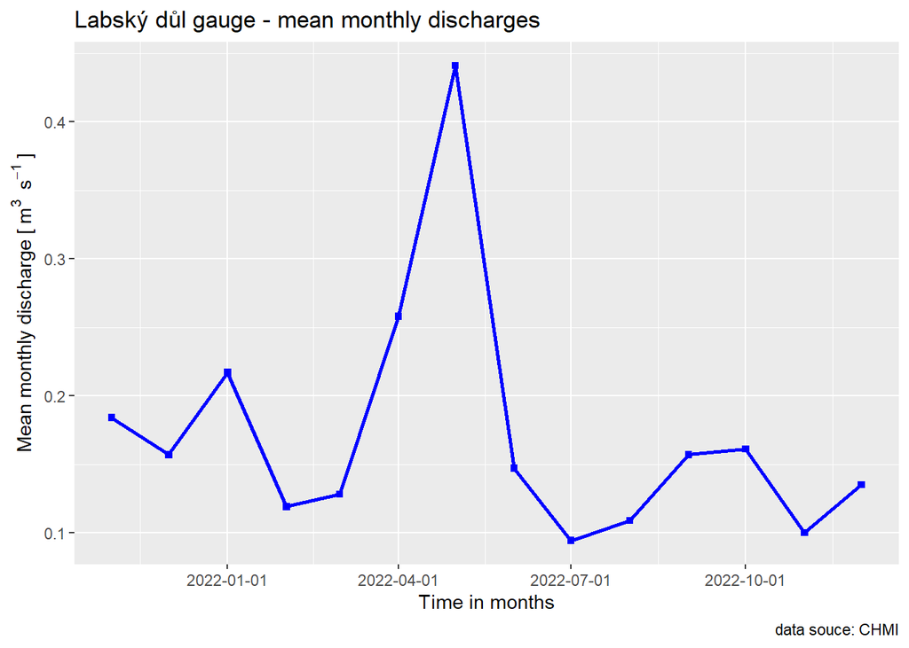

```r
# select the first gauge and plot its monthly time series by using the ggplot2 approach
ggplot(data = qm |>
         filter(ID == "000400") |>
         mutate(date = make_date(year, month))) +
  geom_line(aes(x = date,
                 y = val_num),
            col = "blue",
            lwd = 1) +
  geom_point(aes(x = date,
                 y = val_num),
             col = "blue",
             pch = 15,
             size = 1.5) +
  scale_x_date(date_labels = "%Y-%m-%d") +
  labs(x = "Time in months",
       y = "Mean monthly discharge ["~m^3~""~s^-1~"]",
       title = "Labský důl gauge - mean monthly discharges",
       caption = "data souce: CHMI")
```

In Czechia, each value of mean daily discharge is assigned to the beginning of the day, that is, the midnight of the Central European Time (CET), even in cases when the daylight saving time (CEST) applies. Since R does its best and switches automatically between CET and CEST, we need to overcome this switching. It can be done by using a time zone where the daylight saving time does not apply – eg. UTC. Let us add the information about time to our dates.

```r
# there is no need to add all components, adding hours suffices
qd <- qd |>
  mutate(datetime = make_datetime(year, month, day,
                                  hour = 0,
                                  tz = "UTC"),
         .after = date)

# the time zone is not printed while being in a table
head(qd)
```

```
# A tibble: 6 × 9
  ID     MI    date       datetime            julian  year month   day VAL_NUM
  <chr>  <chr> <date>     <dttm>               <dbl> <dbl> <dbl> <int>   <dbl>
1 000400 QD    2021-10-21 2021-10-21 00:00:00    294  2021    10    21   0.228
2 000400 QD    2021-10-22 2021-10-22 00:00:00    295  2021    10    22   0.174
3 000400 QD    2021-10-23 2021-10-23 00:00:00    296  2021    10    23   0.149
4 000400 QD    2021-10-24 2021-10-24 00:00:00    297  2021    10    24   0.147
5 000400 QD    2021-10-25 2021-10-25 00:00:00    298  2021    10    25   0.144
6 000400 QD    2021-10-26 2021-10-26 00:00:00    299  2021    10    26   0.143
```

```r
# but vectors show it
qd |>
  pull(datetime) |>
  (\(x) x[1])() # this is an anonymous function selecting only the first element
```

```
[1] "2021-10-21 UTC"
```

```r
# we can change the time zone and even add some hours
# so-called Olson names are preffered for time zones
qd |>
  mutate(datetime = datetime |>
           with_tz("Europe/Prague") +
           hours(2)) |>
  pull(datetime) |>
  (\(x) x[1])()
```

```
[1] "2021-10-21 04:00:00 CEST"
```

```r
# however, the function with_tz() is not the same as the function force_tz()
# observe the differences
qd |>
  mutate(datetime = datetime |>
           force_tz("Europe/Prague") +
           hours(2)) |>
  pull(datetime) |>
  (\(x) x[1])()
```

```
[1] "2021-10-21 02:00:00 CEST"
```

## Geodata in R in general

Besides statistical computations, R is quite suitable for working with geodata. Often, we can work with geodata using the tidyverse approaches we already learned. This means we can apply functions like `filter()`, `slice()`, `select()`, `distinct()`, `group_by()`, `mutate()`, `summarize()`, `pull()`, and other tidyverse verbs and helper functions. In case of vector data the `sf` package (Pebesma, 2018) was from the very beginning designed so that the attribute tables could be manipulated by such verbs; and the attribute part of the vector geodata may, therefore, be tibbles. For working with raster geodata, there are mainly packages `terra` (Hijmans, 2024) and `stars` (Pebesma and Bivand, 2023). In `terra`’s approach, for instance, different raster layers may be considered columns. Otherwise, `terra` objects are very close to lists.

Apart from packages designed for manipulating geodata, there are also packages for obtaining such data. For example, we have packages `geodata`, `rnaturalearth`, `RCzechia` and also many packages working with data of the initiative called *Open Street Map*. Some packages does not contain any datasets and, rather, they are exclusively designed for getting the geodata published through various services (e.g. `esri2sf`).

## Vector geodata in R

Nowadays, the `sf` package presents state-of-the-art approaches to manipulating vector geodata in R. The name of the package abbreviates the expression *simple features*. A simple feature is an object that has its attributes (fields) and its own geometry. In using `sf`, we often work with a collection of simple features that form individual rows. Overall, we have data frames here with columns representing the fields and rows representing individual simple features. And of course, data frames may be tibbles. There is one important difference between ordinary tibbles and `sf` tibbles – a geometry column is present for which we need special functions and approaches. Usually, the presence of geometry means that we have to work with *coordinate reference systems* (crs) and transform from one to another.

We will now demonstrate how to load or read such data into R.

```r
# in the past we needed to load geodata from files
# for instance, the T. G. Masaryk Water Research Institute (TGM WRI) has an old-fashioned website for presenting various vector geodata for download (https://www.dibavod.cz/)
# download and unzip the shapefile representing water reservoirs in Czechia
# then, we can read the data, referring to the SHP file
library(sf)
reservoirs <- read_sf("geodata/dib_a05_vodni_nadrze/a05_vodni_nadrze.shp") |>
  filter(!is.na(NAZ_NA))

head(reservoirs)
```

```
Simple feature collection with 6 features and 13 fields
Geometry type: POLYGON
Dimension:     XY
Bounding box:  xmin: -652891.9 ymin: -1019817 xmax: -633262.3 ymax: -995260.9
Projected CRS: S-JTSK / Krovak East North
# A tibble: 6 × 14
  OBJECTID NAZ_NA         NADR_GID KOTA_HLADI HLOUBKA ZATOP_PLOC OBJEM KOTA_HRAZ
     <dbl> <chr>             <dbl>      <dbl>   <dbl>      <dbl> <dbl>     <dbl>
1       72 "Vejsplachy"    1.01e11          0       0          0     0         0
2       79 "Je\u009ekùv …  1.01e11          0       0          0     0         0
3       80 "Stachùv ryb."  1.01e11          0       0          0     0         0
4        1 "Vlèkovický r…  1.01e11          0       0          0     0         0
5       52 "Druhák"        1.01e11          0       0          0     0         0
6      199 "Fejfar"        1.01e11          0       0          0     0         0
# ℹ 6 more variables: KOTA_PRELI <dbl>, KOTA_VYPUS <dbl>, PLOCHA_M2 <dbl>,
#   SHAPE_AREA <dbl>, SHAPE_LEN <dbl>, geometry <POLYGON [m]>
```

```r
# since there is a problem with encoding, we need to specify it in the driver options
reservoirs <- read_sf("geodata/dib_a05_vodni_nadrze/a05_vodni_nadrze.shp",
                      options = "ENCODING=WINDOWS-1250") |>
  filter(!is.na(NAZ_NA))

head(reservoirs)
```

```
Simple feature collection with 6 features and 13 fields
Geometry type: POLYGON
Dimension:     XY
Bounding box:  xmin: -652891.9 ymin: -1019817 xmax: -633262.3 ymax: -995260.9
Projected CRS: S-JTSK / Krovak East North
# A tibble: 6 × 14
  OBJECTID NAZ_NA         NADR_GID KOTA_HLADI HLOUBKA ZATOP_PLOC OBJEM KOTA_HRAZ
     <dbl> <chr>             <dbl>      <dbl>   <dbl>      <dbl> <dbl>     <dbl>
1       72 Vejsplachy      1.01e11          0       0          0     0         0
2       79 Ježkův ryb.     1.01e11          0       0          0     0         0
3       80 Stachův ryb.    1.01e11          0       0          0     0         0
4        1 Vlčkovický ry…  1.01e11          0       0          0     0         0
5       52 Druhák          1.01e11          0       0          0     0         0
6      199 Fejfar          1.01e11          0       0          0     0         0
# ℹ 6 more variables: KOTA_PRELI <dbl>, KOTA_VYPUS <dbl>, PLOCHA_M2 <dbl>,
#   SHAPE_AREA <dbl>, SHAPE_LEN <dbl>, geometry <POLYGON [m]>
```

Specifically, observe the header informing us about the numbers of rows and columns, type of geometry or about the crs used. Notice also the special column with the geometry itself. In case of polygons and linestrings, the geometry should be represented by list of coordinate pairs – points. In case of points, we have the simplest coordinate pair in the geometry column for each simple feature. We may transform and extract the coordinates using the special functions[^2].

In a modern world, however, we do not need to read the vector geodata from saved files. Instead, services such as *web feature services* are becoming more and more important. Some packages come with their own datasets, making use of the cloud storages. Some packages load vector geodata through various APIs offering open data. Let us demonstrate what has been mentioned.

```r
# load a dataset representing 14 administrative regions of Czechia
library(RCzechia)

regions <- kraje()
```

```
RCzechia: downloading remote dataset.
```

```r
regions
```

```
Simple feature collection with 14 features and 3 fields
Geometry type: GEOMETRY
Dimension:     XY
Bounding box:  xmin: 12.09066 ymin: 48.55189 xmax: 18.85927 ymax: 51.05578
Geodetic CRS:  WGS 84
First 10 features:
   KOD_KRAJ KOD_CZNUTS3          NAZ_CZNUTS3                       geometry
1      3018       CZ010   Hlavní město Praha MULTIPOLYGON (((14.49806 50...
2      3026       CZ020     Středočeský kraj POLYGON ((15.16973 49.61046...
3      3034       CZ031       Jihočeský kraj MULTIPOLYGON (((15.4962 48....
4      3042       CZ032        Plzeňský kraj MULTIPOLYGON (((13.60536 49...
5      3051       CZ041     Karlovarský kraj POLYGON ((12.76512 49.93493...
6      3069       CZ042         Ústecký kraj MULTIPOLYGON (((14.2407 50....
7      3077       CZ051       Liberecký kraj POLYGON ((15.59234 50.55852...
8      3085       CZ052 Královéhradecký kraj POLYGON ((15.52137 50.13497...
9      3093       CZ053      Pardubický kraj POLYGON ((15.6393 49.81589,...
10     3107       CZ063        Kraj Vysočina MULTIPOLYGON (((15.02413 49...
```

```r
# load a dataset representing world countries
library(rnaturalearth)

# dataset has many columns, so we limit ourselves to the first six for printing
# notice that after selecting six columns, the geometry column is still here (this behavior is termed 'sticky geometry')
world <- head(countries110)

world |>
  select(1:6)
```

```
Simple feature collection with 6 features and 6 fields
Geometry type: MULTIPOLYGON
Dimension:     XY
Bounding box:  xmin: -180 ymin: -18.28799 xmax: 180 ymax: 83.23324
Geodetic CRS:  WGS 84
       featurecla scalerank LABELRANK                  SOVEREIGNT SOV_A3
1 Admin-0 country         1         6                        Fiji    FJI
2 Admin-0 country         1         3 United Republic of Tanzania    TZA
3 Admin-0 country         1         7              Western Sahara    SAH
4 Admin-0 country         1         2                      Canada    CAN
5 Admin-0 country         1         2    United States of America    US1
6 Admin-0 country         1         3                  Kazakhstan    KA1
  ADM0_DIF                       geometry
1        0 MULTIPOLYGON (((180 -16.067...
2        0 MULTIPOLYGON (((33.90371 -0...
3        0 MULTIPOLYGON (((-8.66559 27...
4        0 MULTIPOLYGON (((-122.84 49,...
5        1 MULTIPOLYGON (((-122.84 49,...
6        1 MULTIPOLYGON (((87.35997 49...
```

```r
# load a dataset representing catchment divides of the first order (Czechia)
library(esri2sf)  # package should be installed after the first lesson

# this is how we load vector geodata from an ArcGIS REST API
# we found the link at https://open-data-chmi.hub.arcgis.com/
catch <- esri2sf("https://services1.arcgis.com/ZszVN9lBVA5x4VmX/arcgis/rest/services/rozvodnice_I_radu/FeatureServer/0",
                 progress = T,
                 crs = NULL)
```

```
Layer Type: Feature Layer
```

```
Geometry Type: esriGeometryPolygon
```

```
Service Coordinate Reference System: 32633
```

```r
catch
```

```
Simple feature collection with 3 features and 7 fields
Geometry type: MULTIPOLYGON
Dimension:     XY
Bounding box:  xmin: 271665.6 ymin: 5369687 xmax: 788210.7 ymax: 5658913
Projected CRS: WGS 84 / UTM zone 33N
  OBJECTID CHP_1R    A_KM2  AA_KM2       NAZ_POV Shape__Area Shape__Length
1        1      1 52892.90 2951.62   povodí Labe 52860323439       1707198
2        2      2  9296.98 2048.99   povodí Odry  9298025806       1324997
3        3      4 26625.60 4941.16 povodí Dunaje 26617184948       1892410
                           geoms
1 MULTIPOLYGON (((457997.6 56...
2 MULTIPOLYGON (((623043 5563...
3 MULTIPOLYGON (((479054.3 53...
```

As the geometry is sticky, we also need special functions to get rid of the geometry, and make from the attribute table a standard table. This function is `st_drop_geometry()` and it may be useful for making the computations faster because the geometry column sometimes delays a lot. Imagine the application of `distinct()` where also the geometry must be modified accordingly.

```r
# drop the geometry from the catch object
catch |>
  st_drop_geometry() |>
  class()
```

```
[1] "data.frame"
```

```r
# we can also rename the geometry column (other approach not recommended)
# function st_set_geometry() switches according to the input type
catch |>
  st_set_geometry("geometry")
```

```
Simple feature collection with 3 features and 7 fields
Geometry type: MULTIPOLYGON
Dimension:     XY
Bounding box:  xmin: 271665.6 ymin: 5369687 xmax: 788210.7 ymax: 5658913
Projected CRS: WGS 84 / UTM zone 33N
  OBJECTID CHP_1R    A_KM2  AA_KM2       NAZ_POV Shape__Area Shape__Length
1        1      1 52892.90 2951.62   povodí Labe 52860323439       1707198
2        2      2  9296.98 2048.99   povodí Odry  9298025806       1324997
3        3      4 26625.60 4941.16 povodí Dunaje 26617184948       1892410
                        geometry
1 MULTIPOLYGON (((457997.6 56...
2 MULTIPOLYGON (((623043 5563...
3 MULTIPOLYGON (((479054.3 53...
```

```r
# by default, the result of esri2sf::esri2sf() is a data.frame, but it can be converted to a tibble
catch <- catch |>
  as_tibble() |>
  st_sf()

world <- world |>
  as_tibble() |>
  st_sf()

catch
```

```
Simple feature collection with 3 features and 7 fields
Geometry type: MULTIPOLYGON
Dimension:     XY
Bounding box:  xmin: 271665.6 ymin: 5369687 xmax: 788210.7 ymax: 5658913
Projected CRS: WGS 84 / UTM zone 33N
# A tibble: 3 × 8
  OBJECTID CHP_1R  A_KM2 AA_KM2 NAZ_POV        Shape__Area Shape__Length
     <int> <chr>   <dbl>  <dbl> <chr>                <dbl>         <dbl>
1        1 1      52893.  2952. povodí Labe   52860323439.      1707198.
2        2 2       9297.  2049. povodí Odry    9298025806.      1324997.
3        3 4      26626.  4941. povodí Dunaje 26617184948.      1892410.
# ℹ 1 more variable: geoms <MULTIPOLYGON [m]>
```

Do not confuse the `st_sf()` function with the `st_as_sf()` function. `st_as_sf()` is probably used most frequently when creating a point simple feature collection from scratch, that is, from given coordinates.

```r
# in the table with metadata, we have some coordinates
# make use of these coordinates (in EPSG 32633) and create a new sf collection
tab_geog <- tab |>
  st_as_sf(coords = c("UTM_X", "UTM_Y"),
           crs = 32633)

head(tab_geog)
```

```
Simple feature collection with 6 features and 9 fields
Geometry type: POINT
Dimension:     XY
Bounding box:  xmin: 538921.7 ymin: 5599115 xmax: 551450.4 ymax: 5623320
Projected CRS: WGS 84 / UTM zone 33N
# A tibble: 6 × 10
  ID     STATION         RIVER     BRANCH CHP           A PCR        SOUV  LINK
  <chr>  <chr>           <chr>     <chr>  <chr>     <dbl> <date>     <chr> <chr>
1 000400 Labský důl      Labe      OAH    1-01-01-…  4.35 2021-10-01 Y     http…
2 001000 Špindlerův Mlýn Labe      HK     1-01-01-… 53.1  1988-11-01 N     http…
3 002000 Labská          Labe      HK     1-01-01-… 61.3  1984-11-01 N     http…
4 003000 Prosečné        Malé Labe HK     1-01-01-… 72.8  1980-11-01 Y     http…
5 003100 Černý Důl       Čistá     HK     1-01-01-…  6.53 1981-11-01 Y     http…
6 004000 Hostinné        Čistá     HK     1-01-01-… 77.4  1980-11-01 N     http…
# ℹ 1 more variable: geometry <POINT [m]>
```

Using the function `st_join()` we can get the attributes from other sf object based on their spatial relationships. Based on these attributes, we can build boxplots of catchment area.

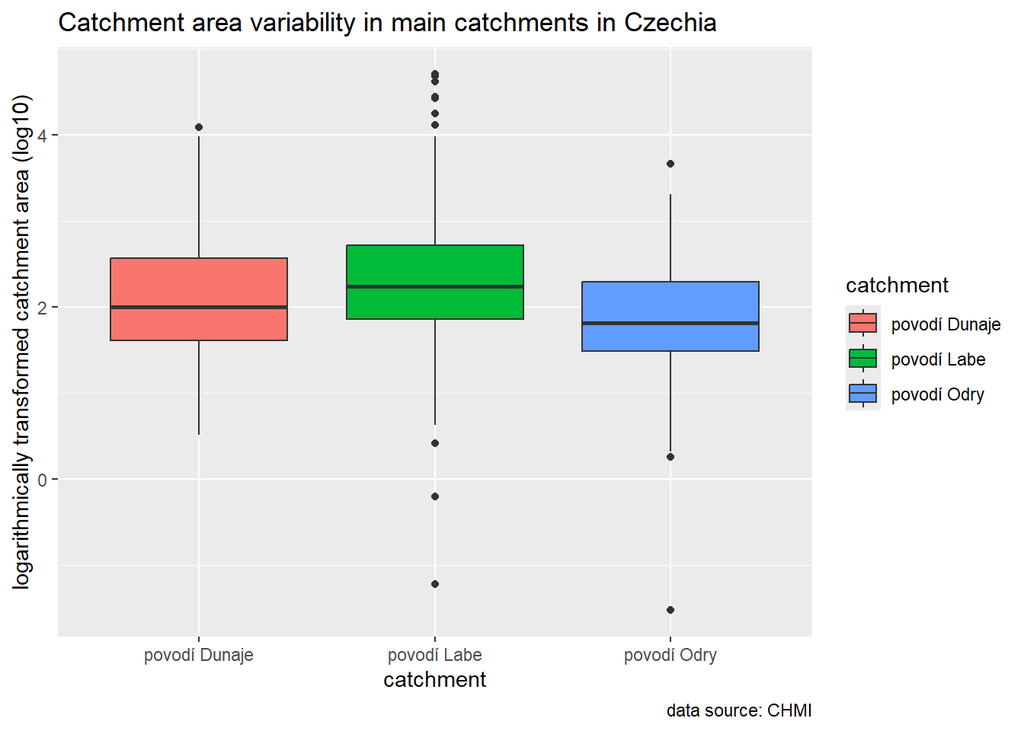

```r
# first, apply the spatial join
tab_geog <- tab_geog |>
  st_join(catch |>
            st_make_valid() |> # necessary because of invalid geometry (can be tested by st_is_valid())
            select(NAZ_POV))

# then, create the boxplot using the ggplot2 approach
ggplot(data = tab_geog) +
  geom_boxplot(aes(y = log10(A), x = NAZ_POV, fill = NAZ_POV)) +
  labs(title = "Catchment area variability in main catchments in Czechia",
       caption = "data source: CHMI",
       x = "catchment",
       y = "logarithmically transformed catchment area (log10)",
       fill = "catchment")
```

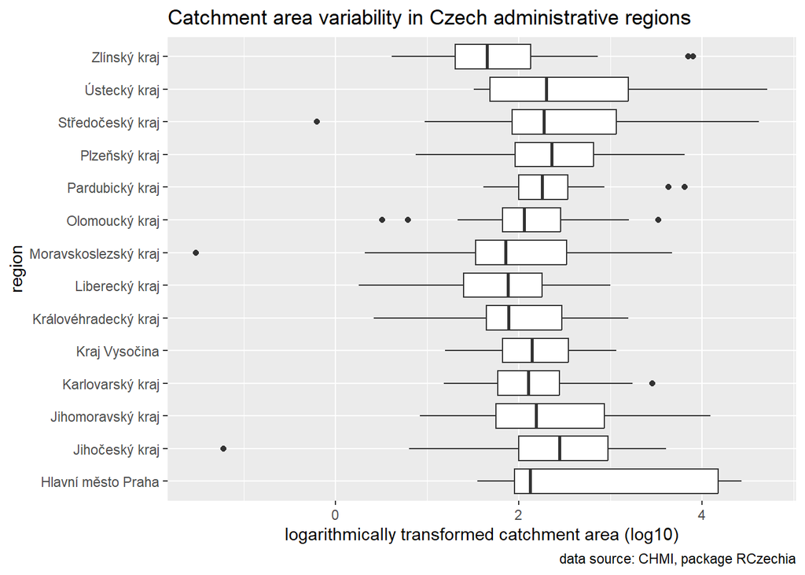

```r
# something similar may be done with administrative regions
# we must transform the crs
regions <- regions |>
  st_transform(32633)

tab_geog <- tab_geog |>
  st_join(regions |>
            select(NAZ_CZNUTS3))

ggplot(data = tab_geog) +
  geom_boxplot(aes(x = log10(A), y = NAZ_CZNUTS3)) +
  labs(title = "Catchment area variability in Czech administrative regions",
       caption = "data source: CHMI, package RCzechia",
       x = "logarithmically transformed catchment area (log10)",
       y = "region")
```

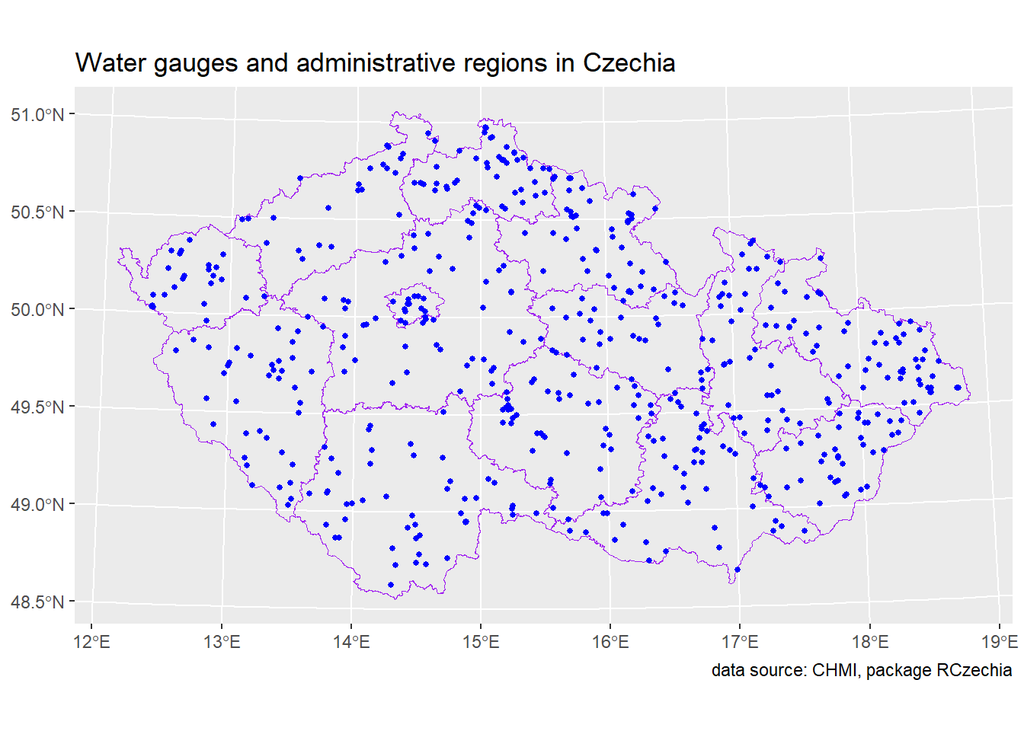

```r
# we can even plot a static map using the ggplot2::geom_sf() function
ggplot() +
  geom_sf(data = regions,
          col = "purple",
          fill = NA) +
  geom_sf(data = tab_geog,
          col = "blue",
          size = 1) +
  labs(title = "Water gauges and administrative regions in Czechia",
       caption = "data source: CHMI, package RCzechia")
```

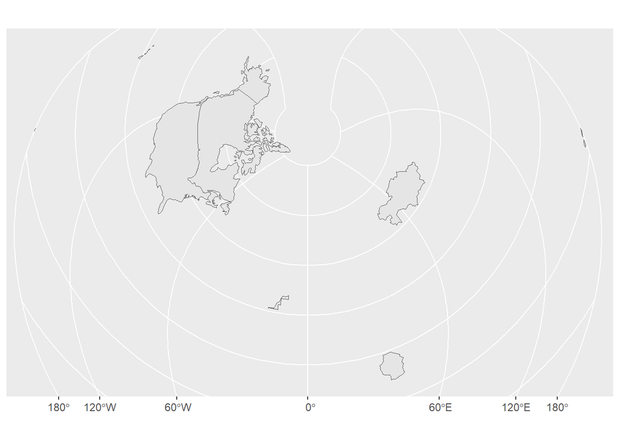

```r
# explore also the package ggspatial whose functions may be used to add a north arrow and a scale bar

# using the geom_sf() function, one could easily create a world map in any projection defined either by an authoriry code or a WKT-2 string
# example of the Bonne projection follows
ggplot() +
  geom_sf(data = world) +
  coord_sf(crs = "ESRI:54024")
```

By default, `st_join()` makes use of the `st_intersects()`, but some other spatial relationships may be examined. These spatial relationships are also very useful when filtering the rows. Suppose, for instance, that we would like to retain only rows with water gauges located in Prague.

```r
# as there is a shortcut using square brackets, let us demonstrate this easier approach
tab_geog_prague <- tab_geog[regions |>
                              filter(NAZ_CZNUTS3 == "Hlavní město Praha"),]

tab_geog_prague
```

```
Simple feature collection with 14 features and 11 fields
Geometry type: POINT
Dimension:     XY
Bounding box:  xmin: 450117 ymin: 5535700 xmax: 468272.5 ymax: 5550768
Projected CRS: WGS 84 / UTM zone 33N
# A tibble: 14 × 12
   ID     STATION             RIVER   BRANCH CHP        A PCR        SOUV  LINK
   <chr>  <chr>               <chr>   <chr>  <chr>  <dbl> <date>     <chr> <chr>
 1 169000 Praha-Zbraslav      Vltava  PR     1-09… 1.78e4 1980-11-01 Y     http…
 2 199200 Praha-Radotín       Beroun… PR     1-11… 8.78e3 2011-01-01 Y     http…
 3 199600 Praha-Radotín       Radotí… PR     1-11… 6.82e1 2006-03-01 Y     http…
 4 200100 Praha-Chuchle       Vltava  PR     1-12… 2.67e4 1985-11-01 Y     http…
 5 200300 Praha-Hlubočepy     Dalejs… PR     1-12… 3.54e1 2022-05-01 Y     http…
 6 200580 Praha-Petrovice     Botič   PR     1-12… 8.76e1 2016-07-01 Y     http…
 7 200590 Praha-Hostivař      Botič   PR     1-12… 9.55e1 2016-07-01 Y     http…
 8 200600 Praha-Nusle         Botič   PR     1-12… 1.35e2 1991-11-01 Y     http…
 9 200700 Praha-Výtoň         Vltava  PR     1-12… 2.69e4 2006-01-01 Y     http…
10 200900 Praha-Na Františku  Vltava  PR     1-12… 2.70e4 2006-01-01 Y     http…
11 200980 Praha-Kyjský rybník Rokytka PR     1-12… 1.15e2 2016-10-01 Y     http…
12 200990 Praha-Vysočany      Rokytka PR     1-12… 1.30e2 2015-01-01 Y     http…
13 201000 Praha-Libeň         Rokytka PR     1-12… 1.37e2 1992-11-01 N     http…
14 201990 Praha-Jiviny        Litovi… PR     1-12… 3.82e1 2019-01-01 Y     http…
# ℹ 3 more variables: geometry <POINT [m]>, NAZ_POV <chr>, NAZ_CZNUTS3 <chr>
```

```r
# other spatial relationships can be defined by the op argument
```

Note that functions `st_intersects()` and `st_intersection()` are different. `st_intersection()` is most frequently used when we need to clip one vector layer by another, usually polygon layer. In addition, this function works with attributes in a sense that it adds fields from the layers used for clipping.

If we want to clip by the bounding box of another vector layer, we use `st_crop()`. When working with large datasets, it is advisable to first crop and then clip. Study the help pages and try using these functions.

## Calculations based on geometry

Very often, we want to calculate the area of a polygon, length of a linestring or other characteristics related to the geometry of a vector layer. For instance, we would like to compute the areas of the three main catchments because we do not believe the numbers that are in the attribute table.

```r
# first, we need to transform to an equal-area crs
# using the units package and its functions, we can even set the resulting units
catch <- catch |>
  st_make_valid() |>
  st_transform(3035) |>
  mutate(a = st_area(geoms),
         a = units::set_units(a, km2))

# we can see that the previous calculations were quite good
catch |>
  select(A_KM2,
         a)
```

```
Simple feature collection with 3 features and 2 fields
Geometry type: GEOMETRY
Dimension:     XY
Bounding box:  xmin: 4450497 ymin: 2827977 xmax: 4969420 ymax: 3116818
Projected CRS: ETRS89-extended / LAEA Europe
# A tibble: 3 × 3
   A_KM2      a                                                            geoms
   <dbl>  [km2]                                                   <GEOMETRY [m]>
1 52893. 52893. POLYGON ((4629229 3115831, 4629282 3115816, 4629339 3115825, 46…
2  9297.  9297. MULTIPOLYGON (((4812413 3063885, 4812432 3063864, 4812453 30638…
3 26626. 26626. MULTIPOLYGON (((4669238 2842445, 4669380 2842453, 4669471 28424…
```

```r
# calculate the perimeter of all three catchments
catch <- catch |>
  mutate(circ = units::set_units(st_perimeter(geoms), km))

catch |>
  select(Shape__Length,
         circ)
```

```
Simple feature collection with 3 features and 2 fields
Geometry type: GEOMETRY
Dimension:     XY
Bounding box:  xmin: 4450497 ymin: 2827977 xmax: 4969420 ymax: 3116818
Projected CRS: ETRS89-extended / LAEA Europe
# A tibble: 3 × 3
  Shape__Length  circ                                                      geoms
          <dbl>  [km]                                             <GEOMETRY [m]>
1      1707198. 1708. POLYGON ((4629229 3115831, 4629282 3115816, 4629339 31158…
2      1324997. 1325. MULTIPOLYGON (((4812413 3063885, 4812432 3063864, 4812453…
3      1892410. 1893. MULTIPOLYGON (((4669238 2842445, 4669380 2842453, 4669471…
```

## Writing vector geodata to files

Since the *shapefile* is an old format, we usually write to other formats when it comes to the files with vector geodata. One of the most popular file format now is a *geopackage* with the suffix .gpkg. If there are issues with the geopackage, we can choose *geojson*. There are more advantages and one of them is that the file is only one and there is a smaller risk of forgetting about transferring all the files.

```r
# similar to reading the files, the suffix defines the driver to be used for saving
# save e.g. the transformed polygons with the main catchments
catch |>
  write_sf("results/main_cathcments_equal-area.gpkg")

catch |>
  write_sf("results/main_catchmets_equal-area.geojson")
```

However, RDS files may also be used for storing vector geodata.

## References

Grolemund, G. and Wickham, H.: Dates and times made easy with lubridate, Journal of Statistical Software, 40, 1–25, https://doi.org/10.18637/jss.v040.i03, 2011.

Hijmans, R. J.: [Terra: Spatial data analysis](https://CRAN.R-project.org/package=terra), 2024.

Pebesma, E.: Simple features for R: standardized support for spatial vector data, The R Journal, 10, 439–446, https://doi.org/10.32614/RJ-2018-009, 2018.

Pebesma, E. J. and Bivand, R.: Spatial Data Science: With Applications in R, CRC Press, Boca Raton, 2023.

Wickham, H., Çetinkaya-Rundel, M., and Grolemund, G.: R for Data Science: Import, Tidy, Transform, Visualize, and Model Data, 2nd ed., O’Reilly Media, Inc, Sebastopol, CA, 2023.

## Footnotes

[^1]: R is very sensitive to time zones, which sometimes poses problems when working with databases where time zones are not considered.
[^2]: Almost all names of `sf` functions start with `st_`.